# Calibration of varbvs and BVSR methods

Peter Carbonetto

September 5, 2017

## Set up experiment

These variables control the settings for simulating the data set and running the algorithms: number of samples (n); number of variables, or genetic markers (p); number of quantitative trait loci (na); variance of the residual (se); proportion of variance in trait explained by QTLs (r); length of Markov chain for simulating from BVSR posterior (ns); candidate values for the prior log-odds of inclusion (logodds); and seed for initializing the random number generator.

```r
n  <- 800
p  <- 2000
na <- 20
se <- 4
r  <- 0.5
ns <- 1e5
logodds <- seq(-3,-1,0.1)
set.seed(1)
```

Next, load a few packages, as well as some additional functions I implemented for this analysis.

```r
library(ggplot2)
library(cowplot)
library(varbvs)
source("../code/gemma.R")
```

## Generate data set

Generate the minor allele frequencies so that they are uniform over range $[0.05, 0.5]$. Then simulate genotypes assuming all markers are uncorrelated (*i.e.*, unlinked), according to the minor allele frequencies specified by vector “maf”.

```r
maf <- 0.05 + 0.45*runif(p)
X   <- (runif(n*p) < maf) +
       (runif(n*p) < maf)
X   <- matrix(as.double(X),n,p,byrow = TRUE)
colnames(X) <- paste0("rs",sample(1e6,p))
```

Generate additive effects for the markers so that exactly “na” of them have a nonzero effect on the trait.

```r
i       <- sample(p,na)
beta    <- rep(0,p)
beta[i] <- rnorm(na)
```

Adjust the QTL effects so that we control for the proportion of variance explained (r). That is, we adjust beta so that $r = a/(a+1)$, where I’ve defined $a = \beta^T \mathrm{cov}(X) \beta$. Here, “sb” is the variance of the (nonzero) QTL effects.

```r
sb   <- r/(1-r)/var(c(X %*% beta))
beta <- sqrt(sb*se) * beta
```

Generate a random intercept.

```r
mu <- rnorm(1)
```

Generate the quantitative trait measurements.

```r
y <- c(mu + X %*% beta + sqrt(se)*rnorm(n))
```

## Fit varbvs model

Fit the fully-factorized variational approximation to the posterior distribution of the coefficients for a linear regression model of a continuous outcome (quantitiative trait), with spike-and-slab priors on the coefficients.

```r
fit.varbvs <- varbvs(X,NULL,y,"gaussian",logodds = logodds,sa = sb)
```

## Fit BVSR model

Fit the the same (or nearly the same) model, but using an MCMC algorithm to simulate the posterior distribution instead of computing approximate posterior probabilities using a variational approximation. In the GEMMA software, this is called the BVSR model, short for “Bayesian variable selection in regression.”

```r
fit.bvsr <- mcmc.bvsr(X,y)
```

## Compare varbvs and BVSR results

Compute the false positive rate (FPR) at each PIP threshold.

```r
fpr  <- data.frame(pip.cutoff = seq(0,1,0.01),varbvs = 0,bvsr = 0)
pip1 <- fit.varbvs$pip
pip2 <- fit.bvsr$pip
fpr[1,-1]   <- 1
fpr[101,-1] <- 0
for (i in 2:100) {
  d <- fpr$pip.cutoff[i]
  fpr$varbvs[i] <- sum(pip1 >= d & beta == 0) / sum(pip1 >= d)
  fpr$bvsr[i]   <- sum(pip2 >= d & beta == 0) / sum(pip2 >= d)
}
```

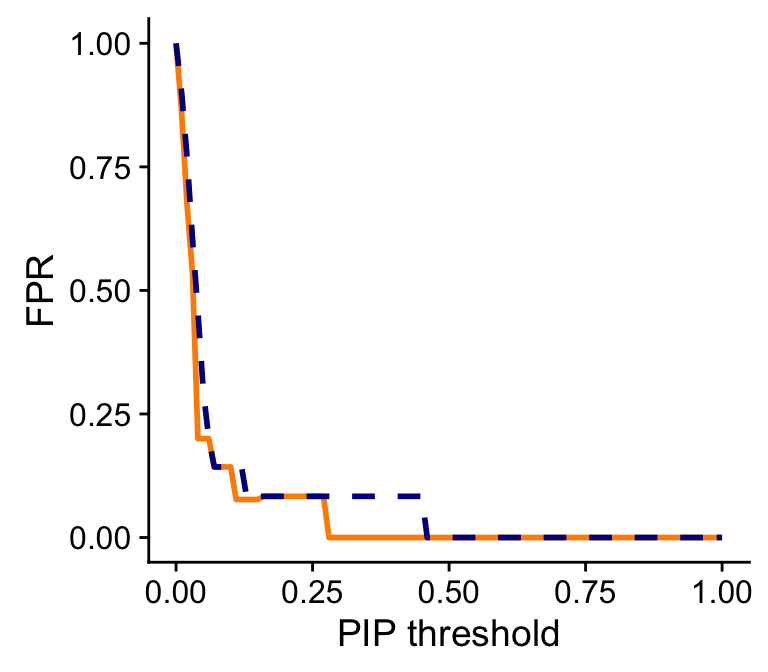

```r
print(ggplot(fpr,aes(x = pip.cutoff)) +
      geom_line(aes(y = varbvs),color = "darkorange",size = 1) +
      geom_line(aes(y = bvsr),color = "darkblue",linetype = "dashed",
                size = 1) +
  labs(x = "PIP threshold",y = "FPR"))
```

## Session information

This is the version of R and the packages that were used to generate these results.

```r
sessionInfo()
# R version 3.4.1 (2017-06-30)
# Platform: x86_64-apple-darwin15.6.0 (64-bit)
# Running under: macOS Sierra 10.12.6
#
# Matrix products: default
# BLAS: /Library/Frameworks/R.framework/Versions/3.4/Resources/lib/libRblas.0.dylib
# LAPACK: /Library/Frameworks/R.framework/Versions/3.4/Resources/lib/libRlapack.dylib
#
# locale:
# [1] en_US.UTF-8/en_US.UTF-8/en_US.UTF-8/C/en_US.UTF-8/en_US.UTF-8
#
# attached base packages:
# [1] stats     graphics  grDevices utils     datasets  methods   base
#
# other attached packages:
# [1] rmarkdown_1.6      varbvs_2.3-5       cowplot_0.8.0
# [4] ggplot2_2.2.1.9000 knitr_1.16
#
# loaded via a namespace (and not attached):
#  [1] Rcpp_0.12.12        magrittr_1.5        munsell_0.4.3
#  [4] colorspace_1.3-2    lattice_0.20-35     rlang_0.1.1
#  [7] stringr_1.2.0       plyr_1.8.4          tools_3.4.1
# [10] grid_3.4.1          gtable_0.2.0        latticeExtra_0.6-28
# [13] htmltools_0.3.6     yaml_2.1.14         lazyeval_0.2.0
# [16] digest_0.6.12       rprojroot_1.2       tibble_1.3.3
# [19] Matrix_1.2-10       RColorBrewer_1.1-2  codetools_0.2-15
# [22] evaluate_0.10.1     labeling_0.3        stringi_1.1.5
# [25] compiler_3.4.1      scales_0.4.1.9002   backports_1.1.0
```